# Unsupervised Learning: Trade&Ahead

###### The clusters in the Ward linkage show better variability

```python
# lets display cluster profile
cluster_profile.style.highlight_max(color="lightgreen", axis=0)
```

| HC_Clusters | Current_Price | Price_Change | Volatility | ROE | Cash_Ratio | Net_Cash_Flow | Net_Income | Earnings_Per_Share | Estimated_Shares_Outstanding | P/E_Ratio | P/B_Ratio | K_means_segments | count_in_each_segments |
| --- | --- | --- | --- | --- | --- | --- | --- | --- | --- | --- | --- | --- | --- |
| 0 | 35.444167 | -15.846623 | 2.887028 | 119.541667 | 43.125000 | -541139583.333333 | -4489833125.000000 | -10.822500 | 514801654.289167 | 83.488426 | 0.897531 | 1.083333 | 24 |
| 1 | 213.518640 | 15.252913 | 1.779861 | 22.333333 | 258.740741 | 1504052814.814815 | 1716529851.851852 | 5.177407 | 689838338.441482 | 78.441603 | 13.022590 | 0.555556 | 27 |
| 2 | 46.672222 | 5.166566 | 1.079367 | 25.000000 | 58.333333 | -3040666666.666667 | 14848444444.444445 | 3.435556 | 4564959946.222222 | 15.596051 | -6.354193 | 2.000000 | 9 |
| 3 | 73.062443 | 4.673490 | 1.399188 | 34.878571 | 54.507143 | 66523982.142857 | 1556658764.285714 | 3.689625 | 443300430.283964 | 24.379506 | -3.214885 | 2.932143 | 280 |

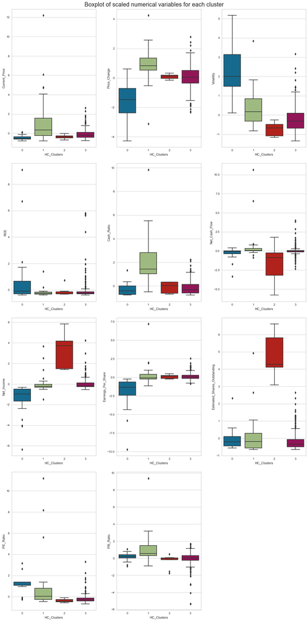

```python
plt.figure(figsize=(15, 30))
plt.suptitle("Boxplot of scaled numerical variables for each cluster", fontsize=20)

for i, variable in enumerate(num_cols):
    plt.subplot(4, 3, i + 1)
    sns.boxplot(data=subset_scaled_df, x="HC_Clusters", y=variable)

plt.tight_layout(pad=2.0)
```

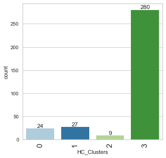

```python
labeled_barplot(df, "HC_Clusters", perc=False)
```

Cluster 0: 24 companies.

Cluster 1: 27 companies.

Cluster 2: 9 companies.

Cluster 3: 280 companies.

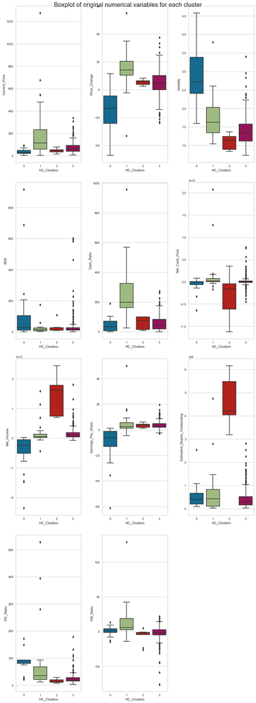

```python
plt.figure(figsize=(12, 40))
plt.suptitle("Boxplot of original numerical variables for each cluster", fontsize=20)

for i, variable in enumerate(num_cols):
    plt.subplot(5, 3, i + 1)
    sns.boxplot(data=df, x="HC_Clusters", y=variable)

plt.tight_layout(pad=2.0)
```

### Insights for Hierarchical Clustering

###### Since there are only 4 clusters, we will be comparing all of them.

###### Cluster 0:

```
There are 24 companies in this cluster.
Has a negative price change, earnings per share and the highest volatility.
However, has the highest ROE of all clusters.
```

###### Cluster 1:

[output not shown]

###### Cluster 2:

```
There are 9 companies in this cluster.
Has a good positive price change and moderate earnings per share and ROE.
Volatility is the lowest of all clusters.
```

###### Cluster 3:

```
There are 280 companies in this cluster
Has a moderate price increase , ROE, earnings per share.
Volatility is also moderate.
```

```python
# importing library
from sklearn.decomposition import PCA

# setting the number of components to 2
pca = PCA(n_components=2)

# transforming data and storing results in a dataframe
X_reduced_pca = pca.fit_transform(subset_scaled_df)
reduced_df_pca = pd.DataFrame(
    data=X_reduced_pca, columns=["Component 1", "Component 2"]
)
```

```python
# checking the amount of variance explained
pca.explained_variance_ratio_.sum()
```

```
0.3781098475238239
```

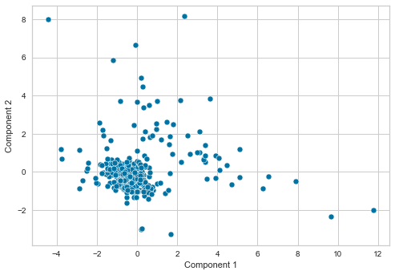

```python
sns.scatterplot(data=reduced_df_pca, x="Component 1", y="Component 2")
```

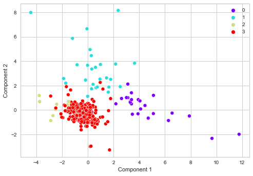

```python
sns.scatterplot(
    data=reduced_df_pca,
    x="Component 1",
    y="Component 2",
    hue=df["HC_Clusters"],
    palette="rainbow",
)
plt.legend(bbox_to_anchor=(1, 1))
```

## K-means vs Hierarchical Clustering

You compare several things, like:

- Which clustering technique took less time for execution?
- Which clustering technique gave you more distinct clusters, or are they the same?
- How many observations are there in the similar clusters of both algorithms?
- How many clusters are obtained as the appropriate number of clusters from both algorithms?

You can also mention any differences or similarities you obtained in the cluster profiles from both the clustering techniques.

##### K-Means technique took less time for execution than Hierarchical Clustering.

###### Both techniques included one large cluster and three smaller clusters.

###### Both clustering techniques had 340 observations.

###### Both clustering techniques gave us 4 clusters as the appropriate amount.

## Actionable Insights and Recommendations

#### K-Means

###### Cluster 0:

- Contains 25 companies.
- Has the highest price change, cash ratio, earnings per share, and P/B Ratio.
- Volatility is moderate to slightly high, and ROE is the lowest of all clusters.
- However, Net Cash Flow is very strong in this cluster.

-Cluster 0 companies are good companies to invest in. Their high price change, earnings per share, and cash ratio should produce good results for the investor. However, the moderate to high volatility make these stocks average to above average risk.

#### Cluster 1:

- Contains 27 companies.
- Has a negative price change along with the highest volatility of all clusters.
- Cash Ratio is low and Earnings per share are negative.
- However, ROE is the highest of all clusters.

-Cluster 1 companies are not good companies to invest in. Their negative price change, high volatility, low cash ratio, and negative earnings per share make these stocks very risky.

#### Cluster 2:

- Contains 11 companies.
- Has a positive price change, good cash flow, and strong earnings per share.
- Volatility is moderate.

-Cluster 2 companies are good companies to invest in. Their positive price change, good cash flow, good earnings, and low to moderate volatility make these stocks low risk. These are good for long term investors.

#### Cluster 3:

- Contains 277 companies.
- Has a moderate price increase, ROE, and cash ratio.
- Earnings per share are also moderate to good.
- However, net cash flow is negative.

-Cluster 3 companies are good companies to invest in. Their moderate price increase, ROE, and cash ration make these stocks a good investment. However, their negative cash flow make these investments moderate risk.

### Hierarchical Clustering

###### Cluster 0:

- There are 24 companies in this cluster.
- Has a negative price change, earnings per share and the highest volatility.
- However, this cluster has the highest ROE of all clusters.

-Cluster 0 companies are not good investments. Even though they have the highest ROE, their negative price change, negative earnings per share, and high volatility make them a very risky investment.

###### Cluster 1:

-Cluster 1 companies are moderately good companies to invest in. Even though they have the lowest ROE of all the clusters, they have the a high price change, strong earnings per share and P/E ratio. Their moderate volatility make them a low to moderate risk.

###### Cluster 2:

- There are 9 companies in this cluster.
- Has a good positive price change and moderate earnings per share and ROE.
- Volatility is the lowest of all clusters.

-Cluster 2 companies are good companies to invest in. Their strong price increase and good earnings per share make them a good choice. Their low volatility make them a low risk and safe investment.

###### Cluster 3:

- There are 280 companies in this cluster
- Has a moderate price increase , ROE, earnings per share.
- Volatility is also moderate.

-Cluster 3 companies are good companies to invest in. Their moderate price increase, ROE, and earnings per share make them a good choice. Their moderate volatility make them a average to slightly risky investment. Investors should be cautious to whether the moderate returns are worth the Volatility risk.